# Arthropod Diversity in a Tropical Forest | Science

Report

# Arthropod Diversity in a Tropical Forest

1. Yves Basset<sup>1</sup>,<sup>2</sup>,<sup>3</sup>,*,
2. Lukas Cizek<sup>2</sup>,<sup>4</sup>,
3. Philippe Cuénoud<sup>5</sup>,
4. Raphael K. Didham<sup>6</sup>,
5. François Guilhaumon<sup>7</sup>,
6. Olivier Missa<sup>8</sup>,
7. Vojtech Novotny<sup>2</sup>,<sup>4</sup>,
8. Frode Ødegaard<sup>9</sup>,
9. Tomas Roslin<sup>10</sup>,
10. Jürgen Schmidl<sup>11</sup>,
11. Alexey K. Tishechkin<sup>12</sup>,
12. Neville N. Winchester<sup>13</sup>,
13. David W. Roubik<sup>1</sup>,
14. Henri-Pierre Aberlenc<sup>14</sup>,
15. Johannes Bail<sup>11</sup>,
16. Héctor Barrios<sup>3</sup>,
17. Jon R. Bridle<sup>15</sup>,
18. Gabriela Castaño-Meneses<sup>16</sup>,
19. Bruno Corbara<sup>17</sup>,
20. Gianfranco Curletti<sup>18</sup>,
21. Wesley Duarte da Rocha<sup>19</sup>,
22. Domir De Bakker<sup>20</sup>,
23. Jacques H. C. Delabie<sup>19</sup>,
24. Alain Dejean<sup>21</sup>,
25. Laura L. Fagan<sup>6</sup>,
26. Andreas Floren<sup>22</sup>,
27. Roger L. Kitching<sup>23</sup>,
28. Enrique Medianero<sup>3</sup>,
29. Scott E. Miller<sup>24</sup>,
30. Evandro Gama de Oliveira<sup>25</sup>,
31. Jérôme Orivel<sup>26</sup>,
32. Marc Pollet<sup>27</sup>,
33. Mathieu Rapp<sup>28</sup>,
34. Sérvio P. Ribeiro<sup>29</sup>,
35. Yves Roisin<sup>30</sup>,
36. Jesper B. Schmidt<sup>31</sup>,
37. Line Sørensen<sup>31</sup>,
38. Maurice Leponce<sup>20</sup>

Science 14 Dec 2012:  
Vol. 338, Issue 6113, pp. 1481-1484  
DOI: 10.1126/science.1226727

## Abstract

Most eukaryotic organisms are arthropods. Yet, their diversity in rich terrestrial ecosystems is still unknown. Here we produce tangible estimates of the total species richness of arthropods in a tropical rainforest. Using a comprehensive range of structured protocols, we sampled the phylogenetic breadth of arthropod taxa from the soil to the forest canopy in the San Lorenzo forest, Panama. We collected 6144 arthropod species from 0.48 hectare and extrapolated total species richness to larger areas on the basis of competing models. The whole 6000-hectare forest reserve most likely sustains 25,000 arthropod species. Notably, just 1 hectare of rainforest yields >60% of the arthropod biodiversity held in the wider landscape. Models based on plant diversity fitted the accumulated species richness of both herbivore and nonherbivore taxa exceptionally well. This lends credence to global estimates of arthropod biodiversity developed from plant models.

Most eukaryote species are terrestrial arthropods (*1*), and most terrestrial arthropods occur in tropical rainforests (*2*). However, considerably greater sampling effort is required in tropical arthropod surveys to yield realistic estimates of global species richness (*3*–*7*). A basic hindrance to estimating global biodiversity lies in a lack of empirical data that establish local biodiversity, which can be scaled up to achieve a global estimate. Although many studies reported species richness for selected groups of well-studied insect taxa, no satisfactory estimate of total arthropod species richness exists for a single tropical rainforest location to date.

The unstructured collection and small-scale survey of tropical arthropods cannot yield convincing estimates of total species richness at a specific forest (*7*–*9*). Most studies either target few arthropod orders or trophic guilds, or use a limited array of sampling methods, or ignore the diverse upper canopy regions of tropical forests (*10*–*15*). Moreover, sampling protocols have rarely been structured in such a way that, with increased sampling, incomplete data on local diversity (*7*) can be extrapolated to estimate total species richness across multiple spatial scales (*16*). Where such structured estimates are made, it is invariably for insect herbivores on their host plants (*5*). However, species accumulation rates may differ markedly for nonherbivore guilds, which include more than half of all described arthropod species (*1*, *17*). As the degree of host specificity (effective specialization) of other guilds can be much lower than that of insect herbivores, or may be driven by different factors (*18*, *19*), global estimates based on herbivores alone are questionable. Consequently, extensive cross-taxon surveys with structured protocols at reference sites may be the only effective approach toward estimating total arthropod species richness in tropical forests (*3*).

To provide a comprehensive estimate of total arthropod species richness in a tropical rainforest, we established a collaboration involving 102 researchers with expertise encompassing the full breadth of phylogenies and feeding modes present among arthropods (*20*). This consortium invested a total of 24,354 trap- (or person-) days sampling the San Lorenzo forest (SLPA) in Panama using structured protocols (fig. S1). We identified 129,494 arthropods representing 6144 focal species (Fig. 1 and table S1) from 0.48 ha of intensively sampled mature forest. This allowed us to extrapolate focal arthropod species richness to a larger forest area with unprecedented power, through a series of best-informed species richness estimates derived from six competing models for each of 18 focal data sets. Using taxon ratios to estimate the species richness of nonfocal taxa [see “Extrapolating results to nonfocal taxa” in materials and methods (*20*)], we then predicted the total species richness of the study area. We also evaluated differences in relative species accumulation rates among arthropod guilds, across spatial scales.

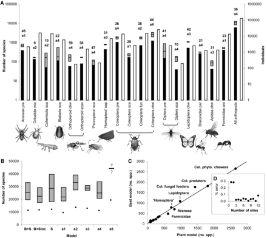

Fig. 1

Number of arthropod species estimated at SLPA (*20*). (**A**) Number of species (closed bars, log scale) and individuals (open bars, log scale) collected in 0.48 ha for each data set (three-letter guild code as in table S1) and number of species estimated in SLPA (best estimate, shaded boxes). Numbers above bars identify the best model used for calculation (a1 to a6, fig. S2) and the percentage of singletons. (**B**) Number of arthropod species estimated for SLPA (dots: all focal taxa; shaded boxes: focal and nonfocal taxa; table S4), as estimated by different methods: B+S: best estimates, including both biological and statistical arguments (table S2); B+Sloc: same as B+S but estimates calculated with local instead of global ratios (fig. S3); S: best estimates, including only statistical arguments; and models a1 to a5. ?: optimization algorithms did not converge to allow calculations of CL. Our estimates are robust to even moderate to large shifts in taxon ratios (table S5). (**C**) Plot of the number of species estimated in SLPA with the plant model against that estimated with the best model, for each data set. Line denotes unity. (**D**) Plot of the percentage error between all arthropod species observed and estimated by the plant model against cumulative number of sites. Shaded boxes indicate means and 95% CL.

Although individual estimators adjusting for different aspects of sampling design offered slightly different estimates (Fig. 1B), the total species richness for the entire San Lorenzo forest (~6000 ha) was consistently quantified at between 18,000 and 44,000 species (including focal and nonfocal species). In particular, the most likely lower bound of species richness was estimated to be at least 21,833 species [95% confidence level (CL) = 18,665, 29,420; model a1 in Fig. 1B], and the biologically and statistically best-supported estimate of richness (criteria outlined in table S2) was 25,246 species (95% CL = 19,721, 33,181, model B+S in Fig. 1B). According to our estimates, a single hectare of rainforest will be inhabited by an average of 18,439 species (95% CL = 17,234, 18,575; Fig. 2B).

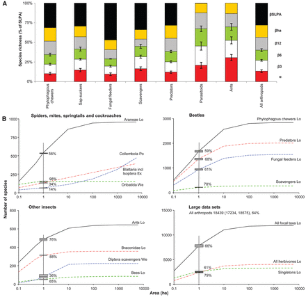

Fig. 2

Despite idiosyncrasies in the rate of increase in sample completeness across insects groups, the high proportion of overall species richness detected at small spatial scales (Figs. 2 and 3) has a remarkable consequence. Based on a general relationship between species numbers and area, we estimate that almost two-thirds (64%) of all species in SLPA occur in a single hectare of rainforest (Fig. 2). Our plant models predicted total arthropod richness in the San Lorenzo forest to a precision of 1% (correlation between richness estimates provided by the plant model and best estimates: *r* = 0.992, *P* < 0.0001, *N* = 18; Fig. 1C). Notably, small discrepancies between observed arthropod species richness and estimates derived from floristic diversity appeared not to be scale-dependent (Fig. 1D). Hence, even for arthropod guilds other than herbivores, plant diversity seems a powerful predictor of species richness across areas varying in size (at least within the limits of our study design and given the limited heterogeneity of the study area compared to larger geographical scales).

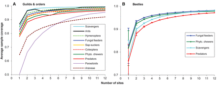

Fig. 3

Average sample coverage [±SEM; error bars, see methods (*20*)] plotted against the cumulative number of sites surveyed, for the main (**A**) arthropod guilds and orders and (**B**) beetle guilds. For the sake of clarity, SEMs are omitted in (A).

Because this study targeted the full spectrum of arthropods, it offers a comprehensive test of previous estimates of species richness based only on selected guilds or taxa. Reassuringly, our well-resolved estimates of tropical arthropod species richness are of the same order of magnitude as prior estimates (table S3), adding credence to recent estimates of tropical arthropod diversity (*5*, *21*). Although the scope for direct comparison is limited because of regional differences in sampling effort, lowland tropical forest in Panama seems to support 2.1 to 8.4 times as many arthropod species as observed in temperate forests (table S3). While this supports the obvious truism that tropical arthropods are indeed more diverse than their temperate counterparts (*22*), the magnitude of that difference is far lower than many previous estimates would suggest (*2*).

The implications of the results observed on a local scale are clear. For every species in the well-known vascular flora (1294 species), avifauna (306 species), and mammalian fauna (81 species) of SLPA, we estimate that there will be a minimum of 17, 71, and 270 arthropod species, respectively (based on lower bound of species richness) and most likely as high as 20, 83, and 312 arthropod species, respectively (table S3). Based on the dominance of arthropod species in the tropical fauna (table S3), we may then argue that conservation planning for biodiversity should be largely determined by the spatial scaling of arthropod diversity. In this context, the association between the species richness of plants and arthropods detected across spatial scales suggests that conservation efforts targeted at floristically diverse sites may also serve to conserve arthropod diversity across both taxonomic lineages and trophic guilds. As arthropods are notoriously labor-intensive to survey, such an “umbrella” approach may be an efficient way forward.

Nonetheless, our findings also suggest that large-scale, region-wide understanding of tropical arthropod richness may actually be more achievable than previously assumed. Our data indicate that a thorough sampling of 1 ha of rainforest may reveal nearly two-thirds of all arthropod species present in a much larger area (6000 ha in our case; Fig. 2B), consistent with reports of relatively low beta diversity of insect herbivores in tropical rainforests (*23*). Hence, to determine the species diversity of a tropical rainforest, the total area sampled need not be overly large—provided that the sampling design adequately covers both microhabitats and plant species. However, this does not imply that most arthropod species have self-supporting populations in small forest areas or fragments.

On a global scale, our results have implications for current estimates of total species richness, which have been weakened by the lack of knowledge regarding the strength of association between vascular plant species and nonherbivore guilds (*5*). Based on the close association observed here between floristic diversity and both herbivore and nonherbivore species richness, we tentatively conclude that the most recent estimate of global tropical arthropod species [6.1 million arthropod species (*24*)] does not require drastic correction to account for differential scaling relationships of nonherbivore taxa. The robust estimates of local arthropod diversity derived in our study thus support previous estimates of global species richness. They also show how stratified sampling designs and broad scientific cooperation may be developed to formulate efficient estimates of tropical arthropod diversity. Similar initiatives have recently been implemented in other tropical locations around the world, using the current template as a foundation (*25*).

## Supplementary Materials

www.sciencemag.org/cgi/content/full/338/6113/1481/DC1

Materials and Methods

Supplementary Text

Figs. S1 to S3

Tables S1 to S5

References (*26**–**151*)

## References and Notes

1. ↵
   1. Z.-Q. Zhang

   , Zootaxa 3148, 99 (2011).

   Google Scholar
2. ↵
   1. T. L. Erwin

   , Coleopt. Bull 36, 74 (1982).

   Google Scholar
3. ↵
   1. R. M. May

   , Tomorrow’s taxonomy: Collecting new species in the field will remain the rate-limiting step. Philos. Trans. R. Soc. Lond. B Biol. Sci. 359, 733 (2004). doi:10.1098/rstb.2003.1455 pmid:15253360

   Abstract/FREE Full TextGoogle Scholar
4. 1. R. M. May

   , Ecology. Tropical arthropod species, more or less? Science 329, 41 (2010). doi:10.1126/science.1191058 pmid:20595603

   Abstract/FREE Full TextGoogle Scholar
5. ↵
   1. A. J. Hamilton
   2. et al

   ., Quantifying uncertainty in estimation of tropical arthropod species richness. Am. Nat. 176, 90 (2010). doi:10.1086/652998 pmid:20455708

   [CrossRef](https://science.sciencemag.org/lookup/external-ref?access_num=10.1086/652998&link_type=DOI)[PubMed](https://science.sciencemag.org/lookup/external-ref?access_num=20455708&link_type=MED&atom=%2Fsci%2F338%2F6113%2F1481.atom)[Web of Science](https://science.sciencemag.org/lookup/external-ref?access_num=000278375200012&link_type=ISI)Google Scholar
6. 1. C. Mora,
   2. D. P. Tittensor,
   3. S. Adl,
   4. A. G. B. Simpson,
   5. B. Worm

   , How many species are there on Earth and in the ocean? PLoS Biol. 9, e1001127 (2011). doi:10.1371/journal.pbio.1001127 pmid:21886479

   [CrossRef](https://science.sciencemag.org/lookup/external-ref?access_num=10.1371/journal.pbio.1001127&link_type=DOI)[PubMed](https://science.sciencemag.org/lookup/external-ref?access_num=21886479&link_type=MED&atom=%2Fsci%2F338%2F6113%2F1481.atom)Google Scholar
7. ↵
   1. J. A. Coddington,
   2. I. Agnarsson,
   3. J. A. Miller,
   4. M. Kuntner,
   5. G. Hormiga

   , Undersampling bias: The null hypothesis for singleton species in tropical arthropod surveys. J. Anim. Ecol. 78, 573 (2009). doi:10.1111/j.1365-2656.2009.01525.x pmid:19245379

   [CrossRef](https://science.sciencemag.org/lookup/external-ref?access_num=10.1111/j.1365-2656.2009.01525.x&link_type=DOI)[PubMed](https://science.sciencemag.org/lookup/external-ref?access_num=19245379&link_type=MED&atom=%2Fsci%2F338%2F6113%2F1481.atom)[Web of Science](https://science.sciencemag.org/lookup/external-ref?access_num=000264784900011&link_type=ISI)Google Scholar
8. 1. Y. Basset

   , Plant Ecol. 153, 87 (2001). doi:10.1023/A:1017581406101

   [CrossRef](https://science.sciencemag.org/lookup/external-ref?access_num=10.1023/A:1017581406101&link_type=DOI)[Web of Science](https://science.sciencemag.org/lookup/external-ref?access_num=000170943700009&link_type=ISI)Google Scholar
9. ↵
   1. T. M. Lewinsohn,
   2. T. Roslin

   , Four ways towards tropical herbivore megadiversity. Ecol. Lett. 11, 398 (2008). doi:10.1111/j.1461-0248.2008.01155.x pmid:18248447

   [CrossRef](https://science.sciencemag.org/lookup/external-ref?access_num=10.1111/j.1461-0248.2008.01155.x&link_type=DOI)[PubMed](https://science.sciencemag.org/lookup/external-ref?access_num=18248447&link_type=MED&atom=%2Fsci%2F338%2F6113%2F1481.atom)Google Scholar
10. ↵
    1. V. Novotny
    2. et al

    ., Local species richness of leaf-chewing insects feeding on woody plants from one hectare of a lowland rainforest. Conserv. Biol. 18, 227 (2004). doi:10.1111/j.1523-1739.2004.00293.x

    [CrossRef](https://science.sciencemag.org/lookup/external-ref?access_num=10.1111/j.1523-1739.2004.00293.x&link_type=DOI)Google Scholar
11. 1. V. Novotny
    2. et al

    ., Guild-specific patterns of species richness and host specialization in plant-herbivore food webs from a tropical forest. J. Anim. Ecol. 79, 1193 (2010). doi:10.1111/j.1365-2656.2010.01728.x pmid:20673235

    [CrossRef](https://science.sciencemag.org/lookup/external-ref?access_num=10.1111/j.1365-2656.2010.01728.x&link_type=DOI)[PubMed](https://science.sciencemag.org/lookup/external-ref?access_num=20673235&link_type=MED&atom=%2Fsci%2F338%2F6113%2F1481.atom)Google Scholar
12. 1. F. Ødegaard

    , Host Specificity, Alpha- and beta-diversity of phytophagous beetles in two tropical forests in Panama. Biodivers. Conserv. 15, 83 (2006). doi:10.1007/s10531-004-3106-5

    [CrossRef](https://science.sciencemag.org/lookup/external-ref?access_num=10.1007/s10531-004-3106-5&link_type=DOI)[Web of Science](https://science.sciencemag.org/lookup/external-ref?access_num=000236032000009&link_type=ISI)Google Scholar
13. 1. J. T. Longino,
    2. J. Coddington,
    3. R. K. Colwell

    , The ant fauna of a tropical rain forest: Estimating species richness three different ways. Ecology 83, 689 (2002). doi:10.1890/0012-9658(2002)083[0689:TAFOAT]2.0.CO;2

    CrossRef[Web of Science](https://science.sciencemag.org/lookup/external-ref?access_num=000173967500011&link_type=ISI)Google Scholar
14. Y. Basset, V. Novotny, S. E. Miller, R. L. Kitching, Eds., *Arthropods of Tropical Forests. Spatio-temporal Dynamics and Resource Use in the Canopy* (Cambridge Univ. Press, Cambridge, 2003).
15. ↵
    1. J. T. Longino,
    2. R. K. Colwell

    , Biodiversity assessment using structured inventory: Capturing the ant fauna of a tropical rain forest. Ecol. Appl. 7, 1263 (1997). doi:10.1890/1051-0761(1997)007[1263:BAUSIC]2.0.CO;2

    CrossRef[Web of Science](https://science.sciencemag.org/lookup/external-ref?access_num=A1997YD79000020&link_type=ISI)Google Scholar
16. ↵
    1. R. K. Colwell,
    2. J. A. Coddington

    , Estimating terrestrial biodiversity through extrapolation. Philos. Trans. R. Soc. Lond. B Biol. Sci. 345, 101 (1994). doi:10.1098/rstb.1994.0091 pmid:7972351

    Abstract/FREE Full TextGoogle Scholar
17. ↵

    D. R. Strong, J. H. Lawton, T. R. E. Southwood, *Insects on Plants. Community Patterns and Mechanisms* (Blackwell, Oxford, ed. 1, 1984).
18. ↵
    1. E. Siemann,
    2. D. Tilman,
    3. J. Haarstad,
    4. M. Ritchie

    , Experimental tests of the dependence of arthropod diversity on plant diversity. Am. Nat. 152, 738 (1998). doi:10.1086/286204 pmid:18811348

    [CrossRef](https://science.sciencemag.org/lookup/external-ref?access_num=10.1086/286204&link_type=DOI)[PubMed](https://science.sciencemag.org/lookup/external-ref?access_num=18811348&link_type=MED&atom=%2Fsci%2F338%2F6113%2F1481.atom)[Web of Science](https://science.sciencemag.org/lookup/external-ref?access_num=000076785900008&link_type=ISI)Google Scholar
19. ↵
    1. V. Novotny,
    2. Y. Basset

    , Host specificity of insect herbivores in tropical forests. Proc. R. Soc. Lond. 272, 1083 (2005). doi:10.1098/rspb.2004.3023

    [PubMed](https://science.sciencemag.org/lookup/external-ref?access_num=16024368&link_type=MED&atom=%2Fsci%2F338%2F6113%2F1481.atom)Google Scholar
20. ↵ Materials and methods are available as supplementary materials on *Science* Online.
21. ↵
    1. V. Novotny
    2. et al

    ., Low host specificity of herbivorous insects in a tropical forest. Nature 416, 841 (2002). doi:10.1038/416841a pmid:11976681

    [CrossRef](https://science.sciencemag.org/lookup/external-ref?access_num=10.1038/416841a&link_type=DOI)[PubMed](https://science.sciencemag.org/lookup/external-ref?access_num=11976681&link_type=MED&atom=%2Fsci%2F338%2F6113%2F1481.atom)Google Scholar
22. ↵
    1. T. C. Bonebrake,
    2. L. C. Ponisio,
    3. C. L. Boggs,
    4. P. R. Ehrlich

    , More than just indicators: A review of tropical butterfly ecology and conservation. Biol. Conserv. 143, 1831 (2010). doi:10.1016/j.biocon.2010.04.044

    [CrossRef](https://science.sciencemag.org/lookup/external-ref?access_num=10.1016/j.biocon.2010.04.044&link_type=DOI)[Web of Science](https://science.sciencemag.org/lookup/external-ref?access_num=000279500800003&link_type=ISI)Google Scholar
23. ↵
    1. V. Novotny
    2. et al

    ., Low beta diversity of herbivorous insects in tropical forests. Nature 448, 692 (2007). doi:10.1038/nature06021 pmid:17687324

    [CrossRef](https://science.sciencemag.org/lookup/external-ref?access_num=10.1038/nature06021&link_type=DOI)[PubMed](https://science.sciencemag.org/lookup/external-ref?access_num=17687324&link_type=MED&atom=%2Fsci%2F338%2F6113%2F1481.atom)Google Scholar
24. ↵
    1. A. J. Hamilton
    2. et al

    ., Correction. Am. Nat. 177, 544 (2011). doi:10.1086/659643

    [CrossRef](https://science.sciencemag.org/lookup/external-ref?access_num=10.1086/659643&link_type=DOI)[Web of Science](https://science.sciencemag.org/lookup/external-ref?access_num=000289237700014&link_type=ISI)[Google Scholar](https://science.sciencemag.org/lookup/google-scholar?link_type=googlescholar&gs_type=article&author[0]=A.%20J.+Hamilton&title=Correction&publication_year=2011&journal=Am.+Nat.&volume=177)
25. ↵
    1. R. L. Kitching
    2. et al

    ., *Mem. Qld Mus.* Mem. Queensl. Mus. Nat. 55, 235 (2011).

    [Google Scholar](https://science.sciencemag.org/lookup/google-scholar?link_type=googlescholar&gs_type=article&author[0]=R.%20L.+Kitching&title=Mem.+Qld+Mus.+&publication_year=2011&journal=Mem.+Queensl.+Mus.+Nat.&volume=55)
26. ↵

    P. L. Weaver, G. P. Bauer, The San Lorenzo Protected Area: A Summary of Cultural and Natural Resources (International Institute of Tropical Forestry, San Juan, 2004).
27. Y. Basset *et al*., IBISCA-Panama, a large-scale study of arthropod beta-diversity and vertical stratification in a lowland rainforest: rationale, description of study sites and field methodology. Bull. Inst R. Sci. Nat. Belgique Ent. 77, 39 (2007).

    Google Scholar
28. J. Schmidl, H. Bussler, in *Canopy Arthropod Research in Europe*, A Floren, J. Schmidl, Eds. (Bioform Entomology, Nuremberg, 2008), pp. 299–323.
29. P. M. Hammond, in *Insects and the Rain Forests of South East Asia (Wallacea)*, W. J. Knight, J. D. Holloway, Eds. (Royal Entomological Society of London, London, 1990), pp. 197–254.
30. R. G. Beutel, R. A. B. Leschen, Eds., *Handbook of Zoology*, part 38, *Coleoptera, Beetles*, vol. 1 (De Gruyter, Berlin, 2005).
31. R. A. B. Leschen, R. G. Beutel, J. F. Lawrence, Eds., *Handbook of Zoology*, part 39, *Coleoptera, Beetles*, vol. 2 (De Gruyter, Berlin, 2010).
32. 1. C. V. Moran,
    2. T. R. E. Southwood

    , The guild composition of arthropod communities in trees. J. Anim. Ecol. 51, 289 (1982). doi:10.2307/4325

    [CrossRef](https://science.sciencemag.org/lookup/external-ref?access_num=10.2307/4325&link_type=DOI)Google Scholar
33. 1. F. Guilhaumon,
    2. D. Mouillot,
    3. O. Gimenez

    , mmSAR: An R-package for multimodel species-area relationship inference. Ecography 33, 420 (2010). doi:10.2307/4325

    [CrossRef](https://science.sciencemag.org/lookup/external-ref?access_num=10.2307/4325&link_type=DOI)[Web of Science](https://science.sciencemag.org/lookup/external-ref?access_num=000279073000024&link_type=ISI)Google Scholar
34. R. K. Colwell, S. Estimate, Statistical Estimation of Species Richness and Shared Species from Samples. Version 8.20. User’s Guide and Application (Univ. of Connecticut, Storrs, 2009); http://purl.oclc.org/estimates.
35. 1. J. Dengler

    , Which function describes the species-area relationship best? A review and empirical evaluation. J. Biogeogr. 36, 728 (2009). doi:10.1111/j.1365-2699.2008.02038.x

    [CrossRef](https://science.sciencemag.org/lookup/external-ref?access_num=10.1111/j.1365-2699.2008.02038.x&link_type=DOI)[Web of Science](https://science.sciencemag.org/lookup/external-ref?access_num=000264073200013&link_type=ISI)Google Scholar
36. D. G. Hyams, CurveExpert Professional. A Comprehensive Data Analysis Software System for Windows, Mac, and Linux. Version 1.2.2 (2011); [www.curveexpert.net](http://www.curveexpert.net/).
37. 1. A. Chao

    , Estimating the population size for capture-recapture data with unequal catchability. Biometrics 43, 783 (1987). doi:10.2307/2531532 pmid:3427163

    [CrossRef](https://science.sciencemag.org/lookup/external-ref?access_num=10.2307/2531532&link_type=DOI)[PubMed](https://science.sciencemag.org/lookup/external-ref?access_num=3427163&link_type=MED&atom=%2Fsci%2F338%2F6113%2F1481.atom)[Web of Science](https://science.sciencemag.org/lookup/external-ref?access_num=A1987L357600004&link_type=ISI)Google Scholar
38. R. L. Chazdon, R. K. Colwell, J. S. Denslow, M. R. Guariguata, in *Forest Biodiversity Research, Monitoring and Modeling: Conceptual Background and Old World Case Studies*, F. Dallmeier, J. A. Comiskey, Eds. (Parthenon, Nashville, TN, 1998), pp. 285–309.
39. 1. U. Brose

    , Estimating species richness of pitfall catches by non-parametric estimators. Pedobiologia (Jena) 46, 101 (2002). doi:10.1078/0031-4056-00117

    [CrossRef](https://science.sciencemag.org/lookup/external-ref?access_num=10.1078/0031-4056-00117&link_type=DOI)Google Scholar
40. 1. J. Hortal,
    2. P. A. V. Borges,
    3. C. Gaspar

    , Evaluating the performance of species richness estimators: Sensitivity to sample grain size. J. Anim. Ecol. 75, 274 (2006). doi:10.1111/j.1365-2656.2006.01048.x pmid:16903065

    [CrossRef](https://science.sciencemag.org/lookup/external-ref?access_num=10.1111/j.1365-2656.2006.01048.x&link_type=DOI)[PubMed](https://science.sciencemag.org/lookup/external-ref?access_num=16903065&link_type=MED&atom=%2Fsci%2F338%2F6113%2F1481.atom)[Web of Science](https://science.sciencemag.org/lookup/external-ref?access_num=000235043700028&link_type=ISI)Google Scholar
41. 1. N. J. Gotelli,
    2. R. K. Colwell

    , Quantifying biodiversity: Procedures and pitfalls in the measurement and comparison of species richness. Ecol. Lett. 4, 379 (2001). doi:10.1046/j.1461-0248.2001.00230.x

    [CrossRef](https://science.sciencemag.org/lookup/external-ref?access_num=10.1046/j.1461-0248.2001.00230.x&link_type=DOI)[Web of Science](https://science.sciencemag.org/lookup/external-ref?access_num=000170417800015&link_type=ISI)Google Scholar
42. 1. J. M. Soberón,
    2. J. B. Llorente

    , The use of species accumulation functions for the prediction of species richness. Conserv. Biol. 7, 480 (1993). doi:10.1046/j.1523-1739.1993.07030480.x

    [CrossRef](https://science.sciencemag.org/lookup/external-ref?access_num=10.1046/j.1523-1739.1993.07030480.x&link_type=DOI)[Web of Science](https://science.sciencemag.org/lookup/external-ref?access_num=A1993LZ05700008&link_type=ISI)Google Scholar
43. 1. G. G. Thompson,
    2. P. C. Withers,
    3. E. R. Pianka,
    4. S. A. Thompson

    , Assessing biodiversity with species accumulation curves: Inventories of small reptiles by pittrapping in Western Australia. Austral Ecol. 28, 361 (2003). doi:10.1046/j.1442-9993.2003.01295.x

    [CrossRef](https://science.sciencemag.org/lookup/external-ref?access_num=10.1046/j.1442-9993.2003.01295.x&link_type=DOI)[Web of Science](https://science.sciencemag.org/lookup/external-ref?access_num=000184384200002&link_type=ISI)Google Scholar
44. 1. O. Arrhenius

    , Species and area. J. Ecol. 9, 95 (1921). doi:10.2307/2255763

    [CrossRef](https://science.sciencemag.org/lookup/external-ref?access_num=10.2307/2255763&link_type=DOI)[Web of Science](https://science.sciencemag.org/lookup/external-ref?access_num=000200150700007&link_type=ISI)[Google Scholar](https://science.sciencemag.org/lookup/google-scholar?link_type=googlescholar&gs_type=article&author[0]=O.+Arrhenius&title=Species+and+area&publication_year=1921&journal=J.+Ecol.&volume=9)
45. 1. M. V. Lomolino

    , Ecology’s most general, yet protean pattern: The species-area relationship. J. Biogeogr. 27, 17 (2000). doi:10.1046/j.1365-2699.2000.00377.x

    [CrossRef](https://science.sciencemag.org/lookup/external-ref?access_num=10.1046/j.1365-2699.2000.00377.x&link_type=DOI)[Web of Science](https://science.sciencemag.org/lookup/external-ref?access_num=000088109600004&link_type=ISI)Google Scholar
46. 1. A. B. Smith

    , Caution with curves: Caveats for using the species-area relationship in conservation. Biol. Conserv. 143, 555 (2010). doi:10.1016/j.biocon.2009.11.003

    [CrossRef](https://science.sciencemag.org/lookup/external-ref?access_num=10.1016/j.biocon.2009.11.003&link_type=DOI)[Web of Science](https://science.sciencemag.org/lookup/external-ref?access_num=000275946400005&link_type=ISI)Google Scholar
47. 1. K. J. Gaston

    , Regional number of insects and plant species. Funct. Ecol. 6, 243 (1992). doi:10.2307/2389513

    [CrossRef](https://science.sciencemag.org/lookup/external-ref?access_num=10.2307/2389513&link_type=DOI)[Web of Science](https://science.sciencemag.org/lookup/external-ref?access_num=A1992JA10900001&link_type=ISI)Google Scholar
48. 1. J. C. Nekola,
    2. P. C. White

    , The distance decay of similarity in biogeography and ecology. J. Biogeogr. 26, 867 (1999). doi:10.1046/j.1365-2699.1999.00305.x

    [CrossRef](https://science.sciencemag.org/lookup/external-ref?access_num=10.1046/j.1365-2699.1999.00305.x&link_type=DOI)[Web of Science](https://science.sciencemag.org/lookup/external-ref?access_num=000084684400013&link_type=ISI)Google Scholar
49. 1. R. Condit
    2. et al

    ., Species-area and species-individual relationships for tropical trees: A comparison of three 50-ha plots. J. Ecol. 84, 549 (1996). doi:10.2307/2261477

    [CrossRef](https://science.sciencemag.org/lookup/external-ref?access_num=10.2307/2261477&link_type=DOI)[Web of Science](https://science.sciencemag.org/lookup/external-ref?access_num=A1996VH80400006&link_type=ISI)Google Scholar
50. 1. T. F. Rangel,
    2. J. A. F. Diniz-Filho,
    3. L. M. Bini

    , SAM: A comprehensive application for Spatial Analysis in Macroecology. Ecography 33, 46 (2010). doi:10.1111/j.1600-0587.2009.06299.x

    [CrossRef](https://science.sciencemag.org/lookup/external-ref?access_num=10.1111/j.1600-0587.2009.06299.x&link_type=DOI)[Web of Science](https://science.sciencemag.org/lookup/external-ref?access_num=000275205200004&link_type=ISI)Google Scholar
51. 1. F. W. Preston

    , The commonness, and rarity, of species. Ecology 29, 254 (1948). doi:10.2307/1930989

    [CrossRef](https://science.sciencemag.org/lookup/external-ref?access_num=10.2307/1930989&link_type=DOI)[Web of Science](https://science.sciencemag.org/lookup/external-ref?access_num=A1948XW59500003&link_type=ISI)Google Scholar
52. 1. R. M. May

    , Unanswered questions in ecology. Philos. Trans. R. Soc. Lond. B Biol. Sci. 354, 1951 (1999). doi:10.1098/rstb.1999.0534 pmid:10670015

    Abstract/FREE Full TextGoogle Scholar
53. 1. B. J. McGill
    2. et al

    ., Species abundance distributions: Moving beyond single prediction theories to integration within an ecological framework. Ecol. Lett. 10, 995 (2007). doi:10.1111/j.1461-0248.2007.01094.x pmid:17845298

    [CrossRef](https://science.sciencemag.org/lookup/external-ref?access_num=10.1111/j.1461-0248.2007.01094.x&link_type=DOI)[PubMed](https://science.sciencemag.org/lookup/external-ref?access_num=17845298&link_type=MED&atom=%2Fsci%2F338%2F6113%2F1481.atom)[Web of Science](https://science.sciencemag.org/lookup/external-ref?access_num=000249275900015&link_type=ISI)Google Scholar
54. 1. R. M. May,
    2. R. J. H. Beverton

    , How many species? Philos. Trans. R. Soc. Lond. B Biol. Sci. 330, 293 (1990). doi:10.1098/rstb.1990.0200

    Abstract/FREE Full TextGoogle Scholar
55. J. Oksanen, R. Kindt, P. Legendre, B. O’Hara, The Vegan Package, Version 1.8-2 (R Foundation for Statistical Computing, Vienna, 2006) ([http://www.Rproject.org](http://www.rproject.org/)).
56. 1. K. I. Ugland,
    2. J. S. Gray,
    3. K. E. Ellingsen

    , The species-accumulation curve and estimation of species richness. J. Anim. Ecol. 72, 888 (2003). doi:10.1046/j.1365-2656.2003.00748.x

    [CrossRef](https://science.sciencemag.org/lookup/external-ref?access_num=10.1046/j.1365-2656.2003.00748.x&link_type=DOI)[Web of Science](https://science.sciencemag.org/lookup/external-ref?access_num=000185063900019&link_type=ISI)Google Scholar
57. D. Agosti, J. D. Majer, L. E. Alonso, T. R. Schultz, Eds, Ants. Standards Methods for Measuring and Monitoring Biodiversity (Smithsonian Institution Press, Washington, DC, 2000).
58. 1. I. D. Hodkinson,
    2. D. A. Casson

    , A lesser predilection for bugs: Hemiptera (Insecta) diversity in tropical rain forests. Biol. J. Linn. Soc. Lond. 43, 101 (1991). doi:10.1111/j.1095-8312.1991.tb00587.x

    [CrossRef](https://science.sciencemag.org/lookup/external-ref?access_num=10.1111/j.1095-8312.1991.tb00587.x&link_type=DOI)[Web of Science](https://science.sciencemag.org/lookup/external-ref?access_num=A1991FV47000002&link_type=ISI)Google Scholar
59. 1. P. M. Hammond

    , Practical approaches to the estimation of the extent of biodiversity in speciose groups. Philos. Trans. R. Soc. Lond. B Biol. Sci. 345, 119 (1994). doi:10.1098/rstb.1994.0092

    Abstract/FREE Full TextGoogle Scholar
60. 1. C. Carlton,
    2. M. Dean,
    3. A. Tishechkin

    , Diversity of two beetle taxa at a Western Amazonian locality (Coleoptera: Histeridae; Staphylinidae, Pselaphinae). Coleopt. Bull. 58, 163 (2004). doi:10.1649/603

    [CrossRef](https://science.sciencemag.org/lookup/external-ref?access_num=10.1649/603&link_type=DOI)[Web of Science](https://science.sciencemag.org/lookup/external-ref?access_num=000222746400003&link_type=ISI)Google Scholar
61. 1. B. J. Finlay,
    2. J. A. Thomas,
    3. G. C. McGavin,
    4. T. Fenchel,
    5. R. T. Clarke

    , Self-similar patterns of nature: Insect diversity at local to global scales. Proc. Biol. Sci. 273, 1935 (2006). doi:10.1098/rspb.2006.3525 pmid:16822755

    Abstract/FREE Full TextGoogle Scholar
62. 1. B. V. Brown

    , Malaise trap catches and the crisis in Neotropical dipterology. Am. Entomol. 51, 180 (2005).

    Google Scholar
63. 1. T. O. Crist,
    2. J. A. Veech,
    3. J. C. Gering,
    4. K. S. Summerville

    , Partitioning species diversity across landscapes and regions: A hierarchical analysis of α, β, and γ diversity. Am. Nat. 162, 734 (2003). doi:10.1086/378901 pmid:14737711

    [CrossRef](https://science.sciencemag.org/lookup/external-ref?access_num=10.1086/378901&link_type=DOI)[PubMed](https://science.sciencemag.org/lookup/external-ref?access_num=14737711&link_type=MED&atom=%2Fsci%2F338%2F6113%2F1481.atom)[Web of Science](https://science.sciencemag.org/lookup/external-ref?access_num=000187724600005&link_type=ISI)Google Scholar
64. 1. A. Chao,
    2. L. Jost

    , Coverage-based rarefaction and extrapolation: Standardizing samples by completeness rather than by size. Ecology 120627111935008 (2012). doi:10.1890/11-1952.1 pmid:23094376

    [CrossRef](https://science.sciencemag.org/lookup/external-ref?access_num=10.1890/11-1952.1&link_type=DOI)[PubMed](https://science.sciencemag.org/lookup/external-ref?access_num=23094376&link_type=MED&atom=%2Fsci%2F338%2F6113%2F1481.atom)Google Scholar
65. 1. A. M. Chickering

    , Additions to the list of known species of spiders from Barro Colorado Island, Panama. Trans. Am. Microsc. Soc. 55, 449 (1936). doi:10.2307/3222528

    [CrossRef](https://science.sciencemag.org/lookup/external-ref?access_num=10.2307/3222528&link_type=DOI)Google Scholar
66. V. Behan-Pelletier, V. Arthropods of La Selva (project ALAS): Oribatida; http://academic.evergreen.edu/projects/ants/ALAStaxa/oribatida/report.jul99.html (1999).
67. 1. L. Subías,
    2. J. P. Zaballos,
    3. E. Banda,
    4. F. Fontal-Cazalla,
    5. J. L. Nieves-Aldrey

    , Acaros oribáitidos (Acari: Oribatei) del Parque Nacional de la isla de Coiba [Oribatid acari (Acari: Oribatei) from Coiba Island National Park, Panamá. (Engl. Transl.)] , Panamá. Rev. Biol. Trop. 52, 85 (2004). pmid:17357403

    [PubMed](https://science.sciencemag.org/lookup/external-ref?access_num=17357403&link_type=MED&atom=%2Fsci%2F338%2F6113%2F1481.atom)[Web of Science](https://science.sciencemag.org/lookup/external-ref?access_num=000223972500012&link_type=ISI)Google Scholar
68. 1. J. Illig,
    2. D. Sandmann,
    3. H. Schatz,
    4. S. Scheu,
    5. M. Maraun

    , Oribatida (mites) - checklist Reserva Biológica San Francisco (Prov. Zamora-Chinchipe, S. Ecuador). Ecotrop. Monogr. 4, 221 (2008).

    Google Scholar
69. 1. E. Franklin,
    2. E. M. R. Santos,
    3. M. I. C. Albuquerque

    , Diversity and distribution of oribatid mites (Acari:Oribatida) in a lowland rain forest in Peru and in several environments of the Brazilians states of Amazonas, Rondônia, Roraima and Pará. Braz. J. Biol. 66, 999 (2006). doi:10.1590/S1519-69842006000600007 pmid:17299936

    [PubMed](https://science.sciencemag.org/lookup/external-ref?access_num=17299936&link_type=MED&atom=%2Fsci%2F338%2F6113%2F1481.atom)Google Scholar
70. 1. J. G. Palacios-Vargas,
    2. G. Castano Meneses,
    3. J. A. Gomez-Anaya

    , Collembola from the canopy of a Mexican tropical decidous forest. Pan-Pac. Entomol. 74, 47 (1998).

    Google Scholar
71. 1. D. J. Rodgers,
    2. R. L. Kitching

    , Vertical stratification of rainforest collembolan (Collembola: Insecta) assemblages: Description of ecological patterns and hypotheses concerning their generation. Ecography 21, 392 (1998). doi:10.1111/j.1600-0587.1998.tb00404.x

    [CrossRef](https://science.sciencemag.org/lookup/external-ref?access_num=10.1111/j.1600-0587.1998.tb00404.x&link_type=DOI)[Web of Science](https://science.sciencemag.org/lookup/external-ref?access_num=000075218800007&link_type=ISI)Google Scholar
72. 1. H. Wolda

    , Diversity, diversity indices and tropical cockroaches. Oecologia 58, 290 (1983). doi:10.1007/BF00385226

    [CrossRef](https://science.sciencemag.org/lookup/external-ref?access_num=10.1007/BF00385226&link_type=DOI)[Web of Science](https://science.sciencemag.org/lookup/external-ref?access_num=A1983QY89200003&link_type=ISI)Google Scholar
73. 1. E. Broadhead,
    2. H. Wolda

    , The diversity of Psocoptera in two tropical forests in Panama. J. Anim. Ecol. 54, 739 (1985). doi:10.2307/4375

    [CrossRef](https://science.sciencemag.org/lookup/external-ref?access_num=10.2307/4375&link_type=DOI)Google Scholar
74. 1. H. Wolda

    , Trends in abundance of tropical forest insects. Oecologia 89, 47 (1992). doi:10.1007/BF00319014

    [CrossRef](https://science.sciencemag.org/lookup/external-ref?access_num=10.1007/BF00319014&link_type=DOI)[Web of Science](https://science.sciencemag.org/lookup/external-ref?access_num=A1992HA23400007&link_type=ISI)Google Scholar
75. I. Hanski, in *Tropical Rain Forest Ecosystems. Biogeographical and Ecological Studies. Ecosystems of the World*, H. Lieth, M. J. A. Werger, Eds. (Elsevier, Amsterdam, 1989), vol. 14B, pp. 489–511.
76. 1. H. Wolda,
    2. C. W. O'Brien,
    3. H. P. Stockwell

    , Weevil diversity and seasonality in tropical Panama as deduced from light-trap catches (Coleoptera: Curculionoidea). Smithson. Contrib. Zool. 590, 1 (1998). doi:10.5479/si.00810282.590

    [CrossRef](https://science.sciencemag.org/lookup/external-ref?access_num=10.5479/si.00810282.590&link_type=DOI)Google Scholar
77. 1. E. M. Fisher

    , A preliminary list of the robberflies (Diptera: Asilidae) of the Tambopata Reserved Zone, Madre de Dios, Peru. Rev. Per. Ent. 27, 25 (1984).

    Google Scholar
78. D. S. Amorim, in *Central American Diptera*, B. Brown, Ed. (Brill, Leiden, Netherlands, 2009), pp. 347–354.
79. 1. G. Brehm,
    2. J. C. Axmacher

    , A comparison of manual and automatic moth sampling methods (Lepidoptera: Arctiidae, Geometridae) in a rain forest in Costa Rica. Environ. Entomol. 35, 757 (2006). doi:10.1603/0046-225X-35.3.757

    [CrossRef](https://science.sciencemag.org/lookup/external-ref?access_num=10.1603/0046-225X-35.3.757&link_type=DOI)Google Scholar
80. 1. W. T. M. Forbes

    , The Lepidoptera of Barro Colorado Island. Bull. Mus. Comp. Zool. 85, 97 (1939).

    Google Scholar
81. 1. W. T. M. Forbes

    , The Lepidoptera of Barro Colorado Island. Bull. Mus. Comp. Zool. 90, 265 (1942).

    Google Scholar
82. 1. D. W. Roubik

    , Direct costs of forest reproduction, bee-cycling and the efficiency of pollination modes. J. Biosci. 18, 537 (1993). doi:10.1007/BF02703085

    [CrossRef](https://science.sciencemag.org/lookup/external-ref?access_num=10.1007/BF02703085&link_type=DOI)[Web of Science](https://science.sciencemag.org/lookup/external-ref?access_num=A1993MY08900009&link_type=ISI)Google Scholar
83. D. W. Roubik, in *Solitary Bees—Conservation, Rearing and Management for Pollination*, B. M. Freitas, J. O. Pereira, Eds. (Imprensa Universitaria, Fortaleza, 2004), pp. 97-103.
84. 1. K. T. Ryder Wilkie,
    2. A. L. Mertl,
    3. J. F. A. Traniello

    , Species diversity and distribution patterns of the ants of Amazonian Ecuador. PLoS ONE 5, e13146 (2010). doi:10.1371/journal.pone.0013146 pmid:20957208

    [CrossRef](https://science.sciencemag.org/lookup/external-ref?access_num=10.1371/journal.pone.0013146&link_type=DOI)[PubMed](https://science.sciencemag.org/lookup/external-ref?access_num=20957208&link_type=MED&atom=%2Fsci%2F338%2F6113%2F1481.atom)Google Scholar
85. 1. J. H. C. Delabie,
    2. C. S. F. Mariano,
    3. I. C. Nascimento

    , As formigas do Município de Ilhéus (Insecta: Hymenoptera: Formicidae). Especiaria 1, 133 (1998).

    Google Scholar
86. L. S. Kimsey, in *Insects of Panama and Mesoamerica. Selected Studies*, D. Quintero, A. Aiello, Eds. (Oxford Univ. Press, Oxford, 1992), pp. 14–24.
87. 1. B. A. Hawkins
    2. et al

    ., Energy, water, and broad-scale geographic patterns of species richness. Ecology 84, 3105 (2003). doi:10.1890/03-8006

    [CrossRef](https://science.sciencemag.org/lookup/external-ref?access_num=10.1890/03-8006&link_type=DOI)[Web of Science](https://science.sciencemag.org/lookup/external-ref?access_num=000187973500001&link_type=ISI)Google Scholar
88. 1. R. S. Condit,
    2. R. Perez,
    3. S. Lao,
    4. S. Aguilar,
    5. A. Somoza

    , Geographic ranges and β- diversity: Discovering how many tree species there are where. Biol. Skrifter 55, 57 (2005).

    Google Scholar
89. G. R. Angehr, D. Engleman, L. Engleman, Where to find birds in Panama. A site guide for birders (Panama Audubon Society, Panama, 2006).
90. R. K. Colwell, J. T. Longino, Arthropods of La Selva; http://viceroy.eeb.uconn.edu/ALAS/ALAS.html (2011).
91. 1. D. Vallauri,
    2. J. Baret

    , J. Naturalité et biodiversité à Païolive. Les Cahiers de Païolive 1, 11 (2008).

    Google Scholar
92. F. Mason, P. Cerretti, A. Tagliapietra, M. C. D. Speight, M. Zapparoli, *Invertebrati di una foresta della Pianura Padana, Bosco della Fontana*, Primo contributo (Gianluigi Arcari Editore, Mantova, 2002).
93. P. Cerretti *et al*., Eds., *Invertebrati di una foresta della Pianura Padana, Bosco della Fontana*, Secondo contributo (Cierre Grafica Editore, Verona, 2004).
94. L. Longo, A. Nadali, Vertebrati di un bosco planiziario padano: Bosco della Fontana (Gianluigi Arcari Editore, Mantova, 2001).
95. G. Persico, La flora della Riserva Naturale Orientata dello stato di Bosco della Fontana (Mn) (Ministero Agricoltura e Foreste, Verona, 1990).
96. M. E. Massey, R. C. Welch, Eds., *Monks Wood National Nature Reserve:Tthe experience of 40 years 1953-93* (English Nature, Peterborough, UK, 1994).
97. 1. National Biodiversity Network

    , http://data.nbn.org.uk (2011).

    Google Scholar
98. R. Rozkošný, J. Vaňhara, Eds., *Invertebrates of the Paláva Biosphere Reserve of the UNESCO*; www.sci.muni.cz/zoolecol/inverteb/palava/ (2011).
99. 1. Z. Řehak,
    2. J. Gaisler,
    3. J. Chytil

    , Vertebrates of the Paláva Biosphere Reserve of UNESCO. Folia Fac. Sci. Nat. Univ. Masaryk. Brun. Biol. 106, 1 (2002).

    Google Scholar
100. P. A. V. Borges *et al*., Eds., *A list of the Terrestrial and Marine Biota from the Azores* (Princípia, Cascais, 2010).
101. S. J. Hubbell, *The Unified Neutral Theory of Biodiversity and Biogeography*, (Princeton Univ. Press, Princeton, NJ, 2001).
102. T. R. Croat, Flora of Barro Colorado Island (Stanford Univ. Press, Palo Alto, CA, 1978).
103. 1. S. A. Slipinski,
     2. R. A. B. Leschen,
     3. J. F. Lawrence

     , Order Coleoptera Linnaeus, 1758. Zootaxa 3148, 203 (2011).

     Google Scholar
104. 1. T. L. Erwin,
     2. J. C. Scott

     , Seasonal and size patterns, trophic structure and richness of Coleoptera in the tropical arboreal ecosystem: The fauna of the tree Luehea seemannii Triana and Planch in the Canal Zone of Panama. Coleopt. Bull. 34, 305 (1980).

     Google Scholar
105. T. L. Erwin, in *Tropical Rain Forest: Ecology and Management*, S. L. Sutton, T. C. Whitmore, A. C. Chadwick, Eds. (Blackwell, Oxford, 1983), pp. 59–76.
106. 1. N. E. Stork

     , The composition of the arthropod fauna of Bornean lowland rain forest trees. J. Trop. Ecol. 7, 161 (1991). doi:10.1017/S0266467400005319

     [CrossRef](https://science.sciencemag.org/lookup/external-ref?access_num=10.1017/S0266467400005319&link_type=DOI)[Web of Science](https://science.sciencemag.org/lookup/external-ref?access_num=A1991FU90300001&link_type=ISI)Google Scholar
107. 1. P. M. Hammond,
     2. R. L. Kitching,
     3. N. E. Stork

     , The composition and richness of the tree-crown Coleoptera assemblage in an Australian subtropical forest. Ecotropica 2, 99 (1996).

     Google Scholar
108. J. G. Davies, N. E. Stork, M. J. D. Brendell, S. J. Hine, in *Canopy Arthropods*, N. E. Stork, J. A. Adis, R. K. Didham, Eds. (Chapman & Hall, London, 1997), pp. 85–103.
109. T. Wagner, in *Canopy Arthropods*, N. E. Stork, J. A. Adis, R. K. Didham, Eds. (Chapman & Hall, London, 1997), pp. 169–183.
110. 1. P. S. Grimbacher,
     2. N. E. Stork

     , Vertical stratification of feeding guilds and body size in beetle assemblages from an Australian tropical rainforest. Austral. Ecol. 32, 77 (2007). doi:10.1111/j.1442-9993.2007.01735.x

     [CrossRef](https://science.sciencemag.org/lookup/external-ref?access_num=10.1111/j.1442-9993.2007.01735.x&link_type=DOI)[Web of Science](https://science.sciencemag.org/lookup/external-ref?access_num=000243697200009&link_type=ISI)Google Scholar
111. 1. A. J. Davis,
     2. S. L. Sutton,
     3. M. J. D. Brendell

     , Vertical distribution of beetles in a tropical rainforest in Sulawesi: The role of the canopy in contributing to biodiversity. Sepilok Bull. 13-14, 59 (2011).

     Google Scholar
112. 1. T. Pape,
     2. V. Blagoderov,
     3. M. Mostovski

     , Order Diptera Linnaeus, 1758. Zootaxa 3148, 222 (2011).

     Google Scholar
113. 1. J. D. Majer,
     2. H. F. Recher,
     3. A. C. Postle

     , Comparison of arthropod species richness in eastern and western Australian canopies: A contribution to the species number debate. Mem. Queensl. Mus. 36, 121 (1994).

     Google Scholar
114. D. P. Reagan, R. B. Waide, Eds., The Food Web of a Tropical Rain Forest (Univ. of Chicago Press, Chicago, 1996).
115. 1. G. Williams

     , A taxonomic and biogeographic review of the invertebrates of the Central Eastern rainforest reserves of Australia (CERRA) World Heritage Area, and adjacent regions. Techn. Rep. Aust. Mus. 16, 1 (2002). doi:10.3853/j.1031-8062.16.2002.1353

     [CrossRef](https://science.sciencemag.org/lookup/external-ref?access_num=10.3853/j.1031-8062.16.2002.1353&link_type=DOI)Google Scholar
116. 1. S. K. Callan,
     2. J. D. Majer,
     3. K. Edwards,
     4. D. Moro

     , Documenting the terrestrial invertebrate fauna of Barrow Island, Western Australia. Aust. J. Ent. 50, 323 (2011). doi:10.1111/j.1440-6055.2011.00818.x

     [CrossRef](https://science.sciencemag.org/lookup/external-ref?access_num=10.1111/j.1440-6055.2011.00818.x&link_type=DOI)Google Scholar
117. A. D. Chapman, *Numbers of Living Species in Australia and the World* (Australian Government, Department of the Environment, Water, Heritage and the Arts, Canberra, ed. 2, 2009).
118. P. J. Gullan, J. H. Martin, in *Encyclopedia of Insects*, V. H. Resh, R. T. Cardé, Eds. (Elsevier, Amsterdam, ed. 2, 2009), pp. 957–967.
119. J. Martin, M. Webb, Hemiptera...It's a Bug's Life (The Natural History Museum, London, 2010); www.nhm.ac.uk/resources-rx/files/26feat_its_a_bugs_life-3013.pdf.
120. 1. Y. Basset

     , The taxonomic composition of the arthropod fauna associated with an Australian rainforest tree. Aust. J. Zool. 39, 171 (1991). doi:10.1071/ZO9910171

     [CrossRef](https://science.sciencemag.org/lookup/external-ref?access_num=10.1071/ZO9910171&link_type=DOI)[Web of Science](https://science.sciencemag.org/lookup/external-ref?access_num=A1991FY57500004&link_type=ISI)Google Scholar
121. 1. Y. Basset,
     2. G. A. Samuelson,
     3. S. E. Miller

     , Similarities and contrasts in the local insect faunas associated with ten forest tree species of New Guinea. Pac. Sci. 50, 157 (1996).

     Google Scholar
122. D. W. Roubik, P. E. Hanson, Abejas de orquídeas de la América tropical: Biología y guía de campo (Instituto Nacional de Biodiversidad, Santo Domingo de Heredia, 2004).
123. 1. J. B. Whitfield,
     2. W.-Y. Choi,
     3. A. A. Valerio,
     4. J. Rodriguez,
     5. A. R. Deans,
     6. Braconidae in The Tree of Life Web Project, Version 10 June 2004

     , ; http://tolweb.org/Braconidae/23447/2004.06.10 (2004).

     Google Scholar
124. D. Agosti, N. F. Johnson, Eds., *Antbase*. World Wide Web electronic publication ([www.antbase.org](http://www.antbase.org/)), version 05/2005 (2005).
125. 1. Hymenoptera Online Database

     , http://hol.osu.edu/ (2011).

     Google Scholar
126. 1. J. S. Noyes

     , The diversity of Hymenoptera in the tropics with special reference to Parasitica in Sulawesi. Ecol. Entomol. 14, 197 (1989). doi:10.1111/j.1365-2311.1989.tb00770.x

     [CrossRef](https://science.sciencemag.org/lookup/external-ref?access_num=10.1111/j.1365-2311.1989.tb00770.x&link_type=DOI)Google Scholar
127. M. J. Scoble, *The Lepidoptera: Form, Function and Diversity* (Oxford Univ. Press, Oxford, ed. 2, 1995).
128. M. J. Scoble, A. Hausmann, Online list of valid and available names of the Geometridae of the World; www.lepbarcoding.org/geometridae/species_checklists.php (2007).
129. 1. A. Solis

     , Phylogenetic studies and modern classification of the Pyraloidea (Lepidoptera). Rev. Col. Ent. 33, 1 (2007).

     Google Scholar
130. 1. H. G. Dyar

     , Report on the Lepidoptera of the Smithsonian Biological Survey of the Panama Canal Zone, Proc. U. S. Nat. Mus. 47, 139 (1914).

     [CrossRef](https://science.sciencemag.org/lookup/external-ref?access_num=10.5479/si.00963801.47-2050.139&link_type=DOI)Google Scholar
131. 1. E. I. Huntington

     , A list of the Rhopalocera of Barro Colorado Island, Canal Zone, Panama. Bull. Am. Mus. Nat. Hist. 113, 191 (1932).

     Google Scholar
132. 1. D. H. Janzen

     , Ecological characterization of a Costa Rican dry forest caterpillar fauna. Biotropica 20, 120 (1988). doi:10.2307/2388184

     Google Scholar
133. 1. H. S. Barlow,
     2. I. P. Woiwod

     , Moth diversity of a tropical forest in Peninsular Malaysia. J. Trop. Ecol. 5, 37 (1989). doi:10.1017/S0266467400003205

     [CrossRef](https://science.sciencemag.org/lookup/external-ref?access_num=10.1017/S0266467400003205&link_type=DOI)[Web of Science](https://science.sciencemag.org/lookup/external-ref?access_num=A1989T699100004&link_type=ISI)Google Scholar
134. 1. R. L. Kitching
     2. et al

     ., Moth assemblages as indicators of environmental quality in remnants of upland Australian rain forest. J. Appl. Ecol. 37, 284 (2000). doi:10.1046/j.1365-2664.2000.00490.x

     [CrossRef](https://science.sciencemag.org/lookup/external-ref?access_num=10.1046/j.1365-2664.2000.00490.x&link_type=DOI)Google Scholar
135. G. W. J. Ades, R. C. Kendrick, Hong Kong Fauna: A Checklist of Selected Taxa, March 2004 (Kadoorie Farm and Botanic Garden Corporation, Hong Kong, ed. 2, 2004).
136. A. Aiello, V. Rodriguez Garcia, V. Osmar Becker, O. Greece, in *Studies on the Biodiversity of the Bahia Honda Region (Veraguas, Panama)*, S. Castroviejo, A. Ibanez, Eds. (Consejo Superior de Investigaciones Científicas, Madrid, 2005), pp. 494–570.
137. 1. G. Brehm

     , Contrasting patterns of vertical stratification in two moth families in a Costa Rican lowland rain forest. Basic Appl. Ecol. 8, 44 (2007). doi:10.1016/j.baae.2006.02.002

     [CrossRef](https://science.sciencemag.org/lookup/external-ref?access_num=10.1016/j.baae.2006.02.002&link_type=DOI)[Web of Science](https://science.sciencemag.org/lookup/external-ref?access_num=000243960500005&link_type=ISI)Google Scholar
138. 1. P. D. Brock,
     2. J. Marshall

     , Order Phasmida Leach. 1815. Zootaxa 3148, 198 (2011).

     Google Scholar
139. 1. S. Ingrisch

     , Order Orthoptera Oliver, 1789. Zootaxa 3148, 195 (2011).

     [Google Scholar](https://science.sciencemag.org/lookup/google-scholar?link_type=googlescholar&gs_type=article&author[0]=S.+Ingrisch&title=Order+Orthoptera+Oliver,+1789&publication_year=2011&journal=Zootaxa&volume=3148)
140. 1. A. Floren,
     2. K. Riede,
     3. S. Ingrisch

     , Diversity of Orthoptera from Bornean lowland rain forest trees. Ecotropica 7, 33 (2001).

     Google Scholar
141. 1. A. H. Strickland

     , A survey of the arthropod soil and litter fauna of some forest reserves and cacao estates in Trinidad, British West Indies. J. Anim. Ecol. 14, 1 (1945). doi:10.2307/1394

     [CrossRef](https://science.sciencemag.org/lookup/external-ref?access_num=10.2307/1394&link_type=DOI)Google Scholar
142. 1. P. G. Olivier,
     2. P. A. J. Ryke

     , Seasonal fluctuation of the mesofauna in soil under Kikuyu grass. Mem. Inst. Invest. Mocambique 7A, 235 (1965).

     Google Scholar
143. 1. G. C. Loots,
     2. P. A. J. Ryke

     , A comparative quantitative study of the micro-arthropods in different types of pasture soils. Zool. Africana 2, 167 (1966).

     Google Scholar
144. 1. R. A. Van den Berg,
     2. P. A. J. Ryke

     , A sytematic-ecological investigation of the acarofauna of the forest floor in Magoebaskloof (South Africa) with special reference to the mesostigmata. Rev. Biol. 6, 157 (1967).

     Google Scholar
145. 1. P. G. Olivier,
     2. P. A. J. Ryke

     , Soil mite populations in the rhizosphre of citrus trees at Zebediela estates, northern Transvaal. Wet. Bydraes Potchefstroom Univ. 17B, 1 (1970).

     Google Scholar
146. 1. D. H. Janzen

     , Sweep samples of tropical foliage insects: Effects of seasons, vegetation types, elevation, time of day and insularity. Ecology 54, 687 (1973). doi:10.2307/1935359

     [CrossRef](https://science.sciencemag.org/lookup/external-ref?access_num=10.2307/1935359&link_type=DOI)[Web of Science](https://science.sciencemag.org/lookup/external-ref?access_num=A1973P857700027&link_type=ISI)Google Scholar
147. 1. S. T. Ahyong
     2. et al

     ., Subphylum Crustacea Brünnich, 1772. Zootaxa 3148, 165 (2011).

     Google Scholar
148. 1. A. H. Strickland

     , The soil fauna of two contrasted plots of land in Trinidad, British West Indies. J. Anim. Ecol. 16, 1 (1947). doi:10.2307/1501

     [CrossRef](https://science.sciencemag.org/lookup/external-ref?access_num=10.2307/1501&link_type=DOI)Google Scholar
149. D. Quintero Arias, in *Studies on the Biodiversity of the Bahia Honda Region (Veraguas, Panama)*, S. Castroviejo, A. Ibanez, Eds. (Consejo Superior de Investigaciones Científicas, Madrid, 2005), pp. 363–491.
150. 1. T. Pape,
     2. V. Blagoderov,
     3. M. B. Mostovski

     , Order Diptera Linnaeus, 1758. Zootaxa 3148, 222 (2011).

     Google Scholar
151. ↵
     1. J. A. Powell

     , Evolution of larval food preferences in Microlepidoptera. Annu. Rev. Entomol. 25, 133 (1980). doi:10.1146/annurev.en.25.010180.001025

     [CrossRef](https://science.sciencemag.org/lookup/external-ref?access_num=10.1146/annurev.en.25.010180.001025&link_type=DOI)[Web of Science](https://science.sciencemag.org/lookup/external-ref?access_num=A1980JA30800007&link_type=ISI)Google Scholar
152. 1. E. J. van Nieukerken
     2. et al

     ., Order Lepidoptera Linnaeus, 1758. Zootaxa 3148, 212 (2011).

     Google Scholar
153. **Acknowledgments:** IBISCA-Panama is an initiative of Pro-Natura International, Océan Vert, the universities Blaise Pascal and of Panama, and the Smithsonian Tropical Research Institute (STRI), with core funding from SolVin-Solvay SA, STRI, the United Nations Environment Programme, the Smithsonian Institution (Walcott Fund), the European Science Foundation, and the Global Canopy Programme. J. Herrera, E. Andrade, M. Samaniego, S. J. Wright, N. Baiben, S. Bechet, J. Belleguic, T. Aubert, K. Jordan, G. Ebersolt, D. Cleyet-Marrel, L. Pyot, O. Pascal, P. Basset, and E. Bauhaus helped with logistics in the field. A. Barba, R. Cabrera, A. Cornejo, I. Díaz, A. F. R. do Carmo, I. C. do Nascimento, E. A. dos Santos, M. González, A. Hernandez, M. Manumbor, M. Mogia, S. Pinzón, B. Pérez, L. S. Ramos-Lacau, and O. Valdez helped with initial sorting of the arthropod and plant material. Data (as of 10 May 2012) have been deposited in the Dryad repository: http://dx.doi.org/10.5061/dryad.f3p75.

[figure not shown]

### [Science](https://science.sciencemag.org/content/338/6113)

Vol 338, Issue 6113  
14 December 2012

## Cited By...

### Subjects

- [Ecology](https://science.sciencemag.org/collection/ecology)

### 26 February 2021

Vol 371, Issue 6532

[figure not shown]

[Table of Contents](http://science.sciencemag.org/content/371/6532)

### Working Life

[figure not shown]